# Prosper Loan Data Exploration

## By Sarah Pedigo

Note: This dataset is from Prosper loan company who specializes in personal loans. A personal loan is a loan for anything that is not a house, car, or college payment. They can be used for weddings, paying off credit card debt, repairing your house, funding a trip, and many other things. Introduction will continue after preliminary wrangling.

### Preliminary data wrangling and cleaning

```python
#importing necessary packages
import matplotlib.pyplot as plt
import numpy as np
import pandas as pd
```

```python
#loading the csv file into a dataframe
data = pd.read_csv('prosperLoanData.csv')
```

```python
#creating copy of file before wrangling
df = data.copy()
```

Question: What does the dataset look like?

```python
#viewing initial dataframe
df.head()
```

|  | ListingKey | ListingNumber | ListingCreationDate | CreditGrade | Term | LoanStatus | ClosedDate | BorrowerAPR | BorrowerRate | LenderYield | ... | LP_ServiceFees | LP_CollectionFees | LP_GrossPrincipalLoss | LP_NetPrincipalLoss | LP_NonPrincipalRecoverypayments | PercentFunded | Recommendations | InvestmentFromFriendsCount | InvestmentFromFriendsAmount | Investors |
| --- | --- | --- | --- | --- | --- | --- | --- | --- | --- | --- | --- | --- | --- | --- | --- | --- | --- | --- | --- | --- | --- |
| 0 | 1021339766868145413AB3B | 193129 | 2007-08-26 19:09:29.263000000 | C | 36 | Completed | 2009-08-14 00:00:00 | 0.16516 | 0.1580 | 0.1380 | ... | -133.18 | 0.0 | 0.0 | 0.0 | 0.0 | 1.0 | 0 | 0 | 0.0 | 258 |
| 1 | 10273602499503308B223C1 | 1209647 | 2014-02-27 08:28:07.900000000 | NaN | 36 | Current | NaN | 0.12016 | 0.0920 | 0.0820 | ... | 0.00 | 0.0 | 0.0 | 0.0 | 0.0 | 1.0 | 0 | 0 | 0.0 | 1 |
| 2 | 0EE9337825851032864889A | 81716 | 2007-01-05 15:00:47.090000000 | HR | 36 | Completed | 2009-12-17 00:00:00 | 0.28269 | 0.2750 | 0.2400 | ... | -24.20 | 0.0 | 0.0 | 0.0 | 0.0 | 1.0 | 0 | 0 | 0.0 | 41 |
| 3 | 0EF5356002482715299901A | 658116 | 2012-10-22 11:02:35.010000000 | NaN | 36 | Current | NaN | 0.12528 | 0.0974 | 0.0874 | ... | -108.01 | 0.0 | 0.0 | 0.0 | 0.0 | 1.0 | 0 | 0 | 0.0 | 158 |
| 4 | 0F023589499656230C5E3E2 | 909464 | 2013-09-14 18:38:39.097000000 | NaN | 36 | Current | NaN | 0.24614 | 0.2085 | 0.1985 | ... | -60.27 | 0.0 | 0.0 | 0.0 | 0.0 | 1.0 | 0 | 0 | 0.0 | 20 |

5 rows × 81 columns

Observation: The dataset includes a vast variety of variables, from the loan number to the lender yield (profit) to credit score.

```python
#viewing complete list of columns
df.columns
```

```
Index(['ListingKey', 'ListingNumber', 'ListingCreationDate', 'CreditGrade',
       'Term', 'LoanStatus', 'ClosedDate', 'BorrowerAPR', 'BorrowerRate',
       'LenderYield', 'EstimatedEffectiveYield', 'EstimatedLoss',
       'EstimatedReturn', 'ProsperRating (numeric)', 'ProsperRating (Alpha)',
       'ProsperScore', 'ListingCategory (numeric)', 'BorrowerState',
       'Occupation', 'EmploymentStatus', 'EmploymentStatusDuration',
       'IsBorrowerHomeowner', 'CurrentlyInGroup', 'GroupKey',
       'DateCreditPulled', 'CreditScoreRangeLower', 'CreditScoreRangeUpper',
       'FirstRecordedCreditLine', 'CurrentCreditLines', 'OpenCreditLines',
       'TotalCreditLinespast7years', 'OpenRevolvingAccounts',
       'OpenRevolvingMonthlyPayment', 'InquiriesLast6Months', 'TotalInquiries',
       'CurrentDelinquencies', 'AmountDelinquent', 'DelinquenciesLast7Years',
       'PublicRecordsLast10Years', 'PublicRecordsLast12Months',
       'RevolvingCreditBalance', 'BankcardUtilization',
       'AvailableBankcardCredit', 'TotalTrades',
       'TradesNeverDelinquent (percentage)', 'TradesOpenedLast6Months',
       'DebtToIncomeRatio', 'IncomeRange', 'IncomeVerifiable',
       'StatedMonthlyIncome', 'LoanKey', 'TotalProsperLoans',
       'TotalProsperPaymentsBilled', 'OnTimeProsperPayments',
       'ProsperPaymentsLessThanOneMonthLate',
       'ProsperPaymentsOneMonthPlusLate', 'ProsperPrincipalBorrowed',
       'ProsperPrincipalOutstanding', 'ScorexChangeAtTimeOfListing',
       'LoanCurrentDaysDelinquent', 'LoanFirstDefaultedCycleNumber',
       'LoanMonthsSinceOrigination', 'LoanNumber', 'LoanOriginalAmount',
       'LoanOriginationDate', 'LoanOriginationQuarter', 'MemberKey',
       'MonthlyLoanPayment', 'LP_CustomerPayments',
       'LP_CustomerPrincipalPayments', 'LP_InterestandFees', 'LP_ServiceFees',
       'LP_CollectionFees', 'LP_GrossPrincipalLoss', 'LP_NetPrincipalLoss',
       'LP_NonPrincipalRecoverypayments', 'PercentFunded', 'Recommendations',
       'InvestmentFromFriendsCount', 'InvestmentFromFriendsAmount',
       'Investors'],
      dtype='object')
```

Observation: There are too many columns to run code effectively. I will get rid of the ones I don't think I will use.

```python
#deleting unwanted columns for ease of use
df= df.drop(columns= ['ListingKey', 'ListingNumber', 'ListingCreationDate',
       'Term', 'ClosedDate', 'BorrowerRate',
       'LenderYield', 'EstimatedEffectiveYield', 'EstimatedLoss',
       'EstimatedReturn', 'ProsperRating (Alpha)', 'ListingCategory (numeric)', 'BorrowerState',
       'Occupation', 'EmploymentStatus', 'EmploymentStatusDuration',
     'CurrentlyInGroup', 'GroupKey',
       'DateCreditPulled',
       'FirstRecordedCreditLine', 'CurrentCreditLines', 'OpenCreditLines',
       'TotalCreditLinespast7years', 'OpenRevolvingAccounts',
       'OpenRevolvingMonthlyPayment', 'InquiriesLast6Months', 'TotalInquiries',
       'CurrentDelinquencies', 'AmountDelinquent', 'DelinquenciesLast7Years',
       'PublicRecordsLast10Years', 'PublicRecordsLast12Months',
        'BankcardUtilization',
       'AvailableBankcardCredit', 'TotalTrades',
       'TradesNeverDelinquent (percentage)', 'TradesOpenedLast6Months',
        'IncomeRange', 'IncomeVerifiable',
        'LoanKey', 'TotalProsperLoans',
       'TotalProsperPaymentsBilled', 'OnTimeProsperPayments',
       'ProsperPaymentsLessThanOneMonthLate',
       'ProsperPaymentsOneMonthPlusLate',
       'ProsperPrincipalOutstanding', 'ScorexChangeAtTimeOfListing',
       'LoanCurrentDaysDelinquent', 'LoanFirstDefaultedCycleNumber',
       'LoanMonthsSinceOrigination', 'LoanNumber', 'LoanOriginalAmount',
       'LoanOriginationDate', 'LoanOriginationQuarter', 'MemberKey',
     'LP_CustomerPayments',
       'LP_CustomerPrincipalPayments', 'LP_InterestandFees', 'LP_ServiceFees',
       'LP_CollectionFees', 'LP_GrossPrincipalLoss', 'LP_NetPrincipalLoss',
       'LP_NonPrincipalRecoverypayments', 'PercentFunded', 'Recommendations',
       'InvestmentFromFriendsCount', 'InvestmentFromFriendsAmount', 'CreditScoreRangeLower', 'CreditScoreRangeUpper',
       'Investors'])
```

```python
#viewing updated head
df.head(15)
```

|  | CreditGrade | LoanStatus | BorrowerAPR | ProsperRating (numeric) | ProsperScore | IsBorrowerHomeowner | RevolvingCreditBalance | DebtToIncomeRatio | StatedMonthlyIncome | ProsperPrincipalBorrowed | MonthlyLoanPayment |
| --- | --- | --- | --- | --- | --- | --- | --- | --- | --- | --- | --- |
| 0 | C | Completed | 0.16516 | NaN | NaN | True | 0.0 | 0.17 | 3083.333333 | NaN | 330.43 |
| 1 | NaN | Current | 0.12016 | 6.0 | 7.0 | False | 3989.0 | 0.18 | 6125.000000 | NaN | 318.93 |
| 2 | HR | Completed | 0.28269 | NaN | NaN | False | NaN | 0.06 | 2083.333333 | NaN | 123.32 |
| 3 | NaN | Current | 0.12528 | 6.0 | 9.0 | True | 1444.0 | 0.15 | 2875.000000 | NaN | 321.45 |
| 4 | NaN | Current | 0.24614 | 3.0 | 4.0 | True | 6193.0 | 0.26 | 9583.333333 | 11000.0 | 563.97 |
| 5 | NaN | Current | 0.15425 | 5.0 | 10.0 | True | 62999.0 | 0.36 | 8333.333333 | NaN | 342.37 |
| 6 | NaN | Current | 0.31032 | 2.0 | 2.0 | False | 5812.0 | 0.27 | 2083.333333 | NaN | 122.67 |
| 7 | NaN | Current | 0.23939 | 4.0 | 4.0 | False | 1260.0 | 0.24 | 3355.750000 | NaN | 372.60 |
| 8 | NaN | Current | 0.07620 | 7.0 | 9.0 | True | 9906.0 | 0.25 | 3333.333333 | NaN | 305.54 |
| 9 | NaN | Current | 0.07620 | 7.0 | 11.0 | True | 9906.0 | 0.25 | 3333.333333 | NaN | 305.54 |
| 10 | NaN | Current | 0.27462 | 4.0 | 7.0 | False | 387.0 | 0.12 | 7500.000000 | NaN | 395.37 |
| 11 | C | Completed | 0.15033 | NaN | NaN | False | 1220.0 | 0.27 | 1666.666667 | NaN | 33.81 |
| 12 | NaN | Past Due (1-15 days) | 0.17969 | 5.0 | 4.0 | False | 8624.0 | 0.18 | 2416.666667 | NaN | 137.39 |
| 13 | NaN | Current | 0.13138 | 6.0 | 8.0 | True | 9171.0 | 0.09 | 5833.333333 | NaN | 275.63 |
| 14 | NaN | Current | 0.11695 | 6.0 | 8.0 | False | 32898.0 | 0.20 | 10833.333333 | NaN | 415.37 |

```python
#getting shape of dataframe
df.shape
```

```
(113937, 11)
```

Observation: This is a large dataset with 113,000 entries!

```python
#getting general information on dataframe
df.info()
```

```
<class 'pandas.core.frame.DataFrame'>
RangeIndex: 113937 entries, 0 to 113936
Data columns (total 11 columns):
CreditGrade                 28953 non-null object
LoanStatus                  113937 non-null object
BorrowerAPR                 113912 non-null float64
ProsperRating (numeric)     84853 non-null float64
ProsperScore                84853 non-null float64
IsBorrowerHomeowner         113937 non-null bool
RevolvingCreditBalance      106333 non-null float64
DebtToIncomeRatio           105383 non-null float64
StatedMonthlyIncome         113937 non-null float64
ProsperPrincipalBorrowed    22085 non-null float64
MonthlyLoanPayment          113937 non-null float64
dtypes: bool(1), float64(8), object(2)
memory usage: 8.8+ MB
```

### Introduction

This is a very large dataset. Structurally, it has over 100,000 entries and 81 columns. The columns include things like APR, borrower's monthly income, and term of loan. The first main feature that I will explore is the relationship Prosper score has with the other selected variables. The second main feature that I will explore is the effect income has on different variables. The features of this dataset that will help me in assessing the main feature include revolving credit balance, debt to income ratio, and reported monthly income. These things are all factored into credit scores, so they give me insight as to what the credit grade and Prosper score were based on.

### Variable definitions

1. CreditGrade- The Credit rating that was assigned at the time the listing went live. Applicable for listings pre-2009 period and will only be populated for those listings.
2. BorrowerAPR- The Borrower's Annual Percentage Rate (APR) for the loan.
3. ProsperRating- (numeric) The Prosper Rating assigned at the time the listing was created: 0 - N/A, 1 - HR, 2 - E, 3 - D, 4 - C, 5 - B, 6 - A, 7 - AA. Applicable for loans originated after July 2009.
4. ProsperScore- A custom risk score built using historical Prosper data. The score ranges from 1-10, with 10 being the best, or lowest risk score. Applicable for loans originated after July 2009.
5. IsBorrowerHomeowner- A Borrower will be classified as a homeowner if they have a mortgage on their credit profile or provide documentation confirming they are a homeowner.
6. RevolvingCreditBalance- Dollars of revolving credit at the time the credit profile was pulled.
7. DebtToIncomeRatio- The debt to income ratio of the borrower at the time the credit profile was pulled. This value is Null if the debt to income ratio is not available. This value is capped at 10.01. (any debt to income ratio larger than 1000% will be returned as 1001%).
8. StatedMonthlyIncome- The monthly income the borrower stated at the time the listing was created.
9. ProsperPrincipalBorrowed- Total principal borrowed on Prosper loans at the time the listing was created. This value will be null if the borrower had no prior loans.
10. MonthlyLoanPayment- The scheduled monthly loan payment.

## Univariate exploration

Question: are there more homeowners or non-homeowners?

```python
#getting counts for homeowners and non-homeowners
df['IsBorrowerHomeowner'].value_counts()
```

```
True     57478
False    56459
Name: IsBorrowerHomeowner, dtype: int64
```

Observation: almost equal distribution between homeowners and non-homeowners.

Question: What is the most common Prosper score?

```python
#grouping by Prosper Score
prosper_score= df.groupby('ProsperScore')
```

```python
#exploring distribution of Prosper score, our main variable of interest
```

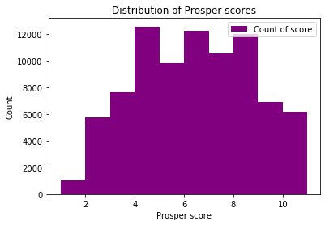

```python
plt.hist(data= df, color= "purple", x= 'ProsperScore', label= "Count of score")
plt.title('Distribution of Prosper scores')
plt.xlabel('Prosper score')
plt.ylabel('Count')
plt.legend()
```

Observation: 4 is the most common score among the whole group. The majority of scores seem to be between 4 and 8.

Question: Does credit grade follow the same pattern as Prosper score?

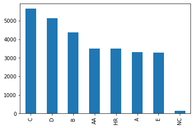

```python
#viewing counts of credit grade
grade = df.CreditGrade.value_counts()
#creating bar plot
grade.plot.bar()
```

Observation: The majority of grades are between B and D. What differs from the Prosper score is the frequency of the highest rating. There is a spike of AA grades in between B and HR (high risk).

Question: What is the most common APR?

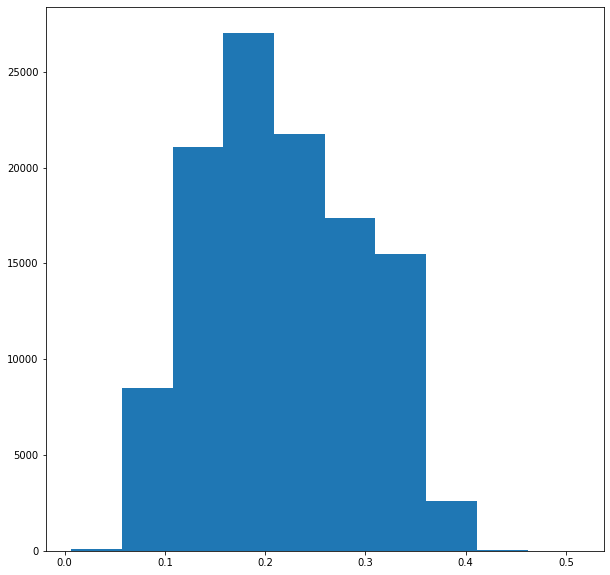

```python
#viewing distribution of APR
plt.figure(figsize= (10,10))
plt.hist(data= df, x= 'BorrowerAPR');
#note: the mode appears to be around .2
```

Observation: the majority of APRs appear to fall within the .15-.25 range.

Question: How many loans are defaulted or past due?

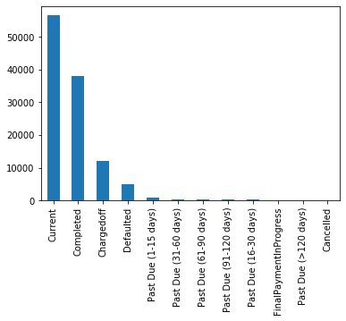

```python
#viewing counts for each loan status
loan_status = df.LoanStatus.value_counts()
loan_status.plot.bar()
```

Observation: The majority of loans are current, with an estimated 55,000 that have that status. Some are defaulted or past due.

Question: What is the range for monthly loan payments?

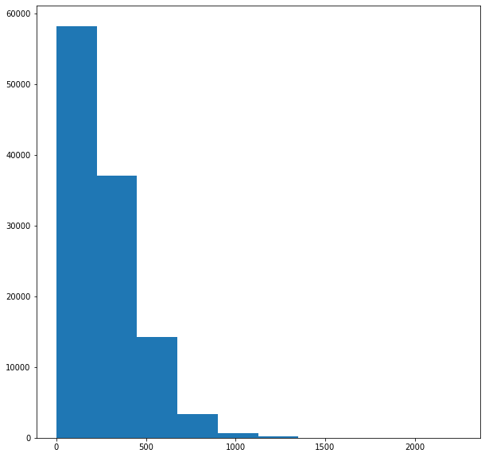

```python
#viewing histogram of monthly loan payments
plt.figure(figsize= (10,10))
plt.hist(data= df, x= 'MonthlyLoanPayment');
```

Observation: an estimated 80-90% of payments fall below $500 with most falling below 300-350

## Bivariate variable exploration

### Investigating factors that affect Prosper scores

Question to be answered throughout this section: How does Prosper score relate to the other selected variables?

Question: Does a low Prosper Score mean a high monthly payment?

```python
#getting summary statistics for monthly loan payments by Prosper score
prosper_score['MonthlyLoanPayment'].mean()
```

```
ProsperScore
1.0     194.586794
2.0     201.763748
3.0     251.543562
4.0     283.417277
5.0     282.898049
6.0     299.785825
7.0     316.424203
8.0     319.987216
9.0     295.291650
10.0    336.399935
11.0    424.037527
Name: MonthlyLoanPayment, dtype: float64
```

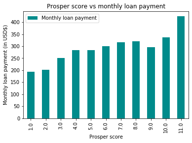

```python
payment= prosper_score['MonthlyLoanPayment'].mean()
payment.plot.bar(color= "darkcyan", label= "Monthly loan payment")
plt.title('Prosper score vs monthly loan payment')
plt.xlabel('Prosper score')
plt.ylabel('Monthly loan payment (in USD$)')
plt.legend()
```

Observation: 11 has the highest mean payment, followed by 10, then 8. Those that were given a high Prosper score also have a high payment. Could this be because of a higher loan amount?

Question: Is Prosper Score affected by monthly income?

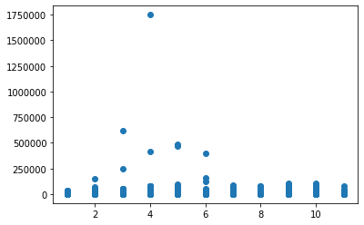

```python
#looking at the Prosper score and monthly income variables together
plt.scatter(x= df['ProsperScore'], y= df['StatedMonthlyIncome'])
#note: no major discernable pattern with this visual, outlier is affecting graph
```

Observation: Outlier is skewing graph.

```python
#filtering out outliers (those with a monthly income over $8,000)
df= df[df['StatedMonthlyIncome'] <= 8000]
```

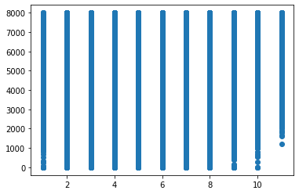

```python
]#recreating graph with edited data set
plt.scatter(x= df['ProsperScore'], y= df['StatedMonthlyIncome'])
```

Observation: From this graph we can see that montly income has a large range for each Prosper score, suggesting that this variable does not have a definitive effect on it. I will further analyze this pattern.

```python
#looking at the prosper score and monthly income variables numerically
prosper_score['StatedMonthlyIncome'].describe()
```

| ProsperScore | count | mean | std | min | 25% | 50% | 75% | max |
| --- | --- | --- | --- | --- | --- | --- | --- | --- |
| 1.0 | 992.0 | 5754.616515 | 4072.274741 | 0.0 | 3313.416667 | 4744.041666 | 6943.416667 | 3.333333e+04 |
| 2.0 | 5766.0 | 5125.151838 | 3973.235721 | 0.0 | 3000.000000 | 4292.916667 | 6250.000000 | 1.500000e+05 |
| 3.0 | 7642.0 | 5329.484406 | 8408.487296 | 0.0 | 3082.083334 | 4333.333333 | 6291.666667 | 6.185478e+05 |
| 4.0 | 12595.0 | 5444.730554 | 16458.545872 | 0.0 | 3166.666667 | 4500.000000 | 6416.666667 | 1.750003e+06 |
| 5.0 | 9813.0 | 5422.756709 | 7684.943003 | 0.0 | 3250.000000 | 4583.333333 | 6500.000000 | 4.833333e+05 |
| 6.0 | 12278.0 | 5541.141975 | 5230.474051 | 0.0 | 3333.333333 | 4750.000000 | 6666.666667 | 3.944000e+05 |
| 7.0 | 10597.0 | 5930.778286 | 4033.930217 | 0.0 | 3591.666667 | 5166.666667 | 7083.333333 | 9.166667e+04 |
| 8.0 | 12053.0 | 6390.269145 | 4401.809933 | 0.0 | 3833.333333 | 5416.666667 | 7666.750000 | 7.500000e+04 |
| 9.0 | 6911.0 | 6774.817646 | 4672.082121 | 0.0 | 4166.666667 | 5833.333333 | 8333.333333 | 1.087500e+05 |
| 10.0 | 4750.0 | 7976.752947 | 5313.327701 | 0.0 | 5000.000000 | 6916.666667 | 9583.333333 | 1.083333e+05 |
| 11.0 | 1456.0 | 8849.659226 | 5379.727678 | 1200.0 | 5416.666667 | 7500.000000 | 10833.333333 | 7.666667e+04 |

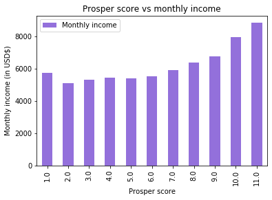

```python
income_score=prosper_score['StatedMonthlyIncome'].mean()
income_score.plot.bar(color="mediumpurple", label= "Monthly income")
plt.title('Prosper score vs monthly income')
plt.xlabel('Prosper score')
plt.ylabel('Monthly income (in USD$)')
plt.legend()
```

Question: What is the difference in income between those with a score of 1 and those with a score of 11?

```python
#calculating mean yearly income for those with rating 11
income_11=12*8849
#note: mean yearly income for the rating 11 subgroup is 106,188
```

```python
#calculating mean yearly income for those with rating 1
income_1=12*5754
#note: mean yearly income for those with rating 1 is 69,048
```

```python
#calculating range
income_range= income_11 - income_1
income_range
```

```
37140
```

Observation: The mean income range from scores 1 to 11 is 37,140, a significant difference.

Question: Does being a homeowner affect Prosper score?

```python
#creating subgroup with homeowners
homeowner= df.query('IsBorrowerHomeowner == True')
homeowner['ProsperScore'].value_counts()
#note: mode for homeowner's prosper score is 4.
```

```
4.0     5026
6.0     4832
8.0     4613
7.0     4079
5.0     4071
3.0     3020
9.0     2658
2.0     2311
10.0    1739
11.0     475
1.0      466
Name: ProsperScore, dtype: int64
```

```python
#creating subgroup with non-homeowners
not_homeowner= df.query('IsBorrowerHomeowner == False')
not_homeowner['ProsperScore'].value_counts()
#note: mode for non-homeowner's score is 4.
```

```
4.0     5859
6.0     5525
8.0     4694
7.0     4547
5.0     4337
3.0     3566
2.0     2715
9.0     2421
10.0    1192
1.0      340
11.0     317
Name: ProsperScore, dtype: int64
```

Observation: There is a small difference when you compare the order of frequency of scores between homeowners and not homeowners.

Question: Does loan status affect Prosper Score?

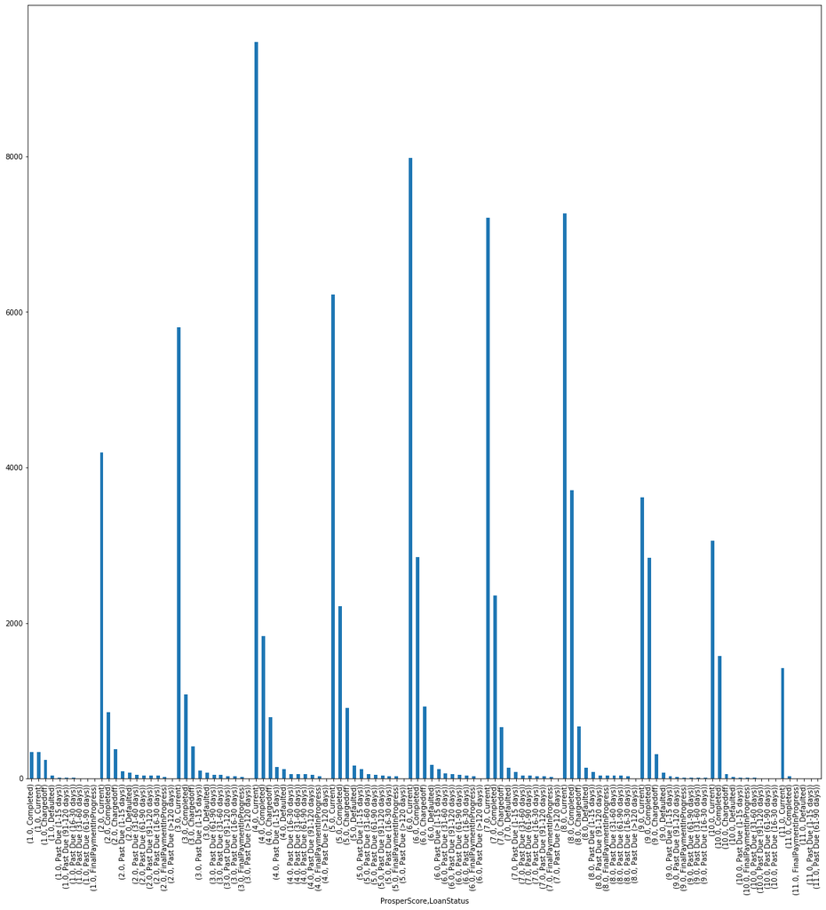

```python
#grouping by Prosper Score
score_loan= prosper_score['LoanStatus'].value_counts()
score_loan.plot.bar(figsize= (20, 20))
```

Question: Does Prosper score have the same relationship with revolving credit balance that credit grade does?

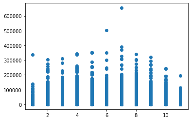

```python
# comparing Prosper score and revolving credit balance
plt.scatter(x= df['ProsperScore'], y = df['RevolvingCreditBalance'])
#note: the mid grade scores have the highest revolving credit balance
```

Observation: It does not. The middle scores have the highest balances.

Question: Why do mid-grade scores have the highest revolving credit balance?

```python
#investigating
prosper_score['RevolvingCreditBalance'].describe()
```

| ProsperScore | count | mean | std | min | 25% | 50% | 75% | max |
| --- | --- | --- | --- | --- | --- | --- | --- | --- |
| 1.0 | 992.0 | 15622.334677 | 30083.048006 | 0.0 | 1548.50 | 5929.0 | 16321.50 | 337034.0 |
| 2.0 | 5766.0 | 17199.272633 | 31413.235872 | 0.0 | 3623.25 | 8274.5 | 18381.25 | 657033.0 |
| 3.0 | 7642.0 | 16594.023031 | 27252.021240 | 0.0 | 4123.75 | 9239.0 | 18685.75 | 597122.0 |
| 4.0 | 12595.0 | 16789.526955 | 29450.853439 | 0.0 | 4233.00 | 9033.0 | 18834.50 | 999165.0 |
| 5.0 | 9813.0 | 17632.427494 | 32339.909124 | 0.0 | 3716.00 | 9234.0 | 20085.00 | 913922.0 |
| 6.0 | 12278.0 | 16699.001547 | 27877.015142 | 0.0 | 3702.00 | 9056.0 | 19210.75 | 878859.0 |
| 7.0 | 10597.0 | 18047.181844 | 32596.835623 | 0.0 | 3734.00 | 9351.0 | 20371.00 | 976426.0 |
| 8.0 | 12053.0 | 18773.438812 | 33033.331197 | 0.0 | 3619.00 | 9568.0 | 21374.00 | 879891.0 |
| 9.0 | 6911.0 | 19093.892635 | 31124.726219 | 0.0 | 3832.00 | 10009.0 | 22132.00 | 577131.0 |
| 10.0 | 4750.0 | 22279.920632 | 38824.711600 | 0.0 | 3995.25 | 10744.0 | 25989.00 | 681968.0 |
| 11.0 | 1456.0 | 24705.968407 | 37126.160306 | 0.0 | 4894.00 | 14215.0 | 30505.50 | 460967.0 |

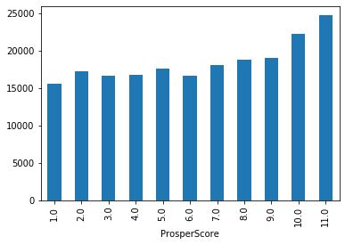

```python
#using plot to view data
balance= prosper_score['RevolvingCreditBalance'].mean()
balance.plot.bar()
```

Observation: looking at it this way, I can see that the high balances in the middle of the scatterplot are outliers. When combined with the majority, balance increases with score as expected.

Question: Does Prosper score affect borrower APR?

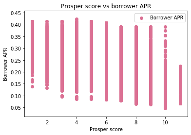

```python
plt.scatter(x= df['ProsperScore'], y=df['BorrowerAPR'], color= "palevioletred", label= "Borrower APR")
plt.title('Prosper score vs borrower APR')
plt.xlabel('Prosper score')
plt.ylabel('Borrower APR')
plt.legend()
```

Observation: Those with a lower Prosper score have a higher APR.

### Exploring other relationships

Question: Is there a relationship between Credit Grade and revolving credit balance?

```python
credit_grade= df.groupby('CreditGrade')
```

```python
#comparing credit grade and revolving credit balance
credit_grade['RevolvingCreditBalance'].describe()
```

| CreditGrade | count | mean | std | min | 25% | 50% | 75% | max |
| --- | --- | --- | --- | --- | --- | --- | --- | --- |
| A | 2344.0 | 19175.790956 | 38119.988870 | 0.0 | 1683.0 | 7200.5 | 20667.00 | 573692.0 |
| AA | 2203.0 | 14832.084884 | 32085.234222 | 0.0 | 1253.0 | 5032.0 | 15105.00 | 503513.0 |
| B | 3131.0 | 18230.796551 | 32206.853700 | 0.0 | 2006.5 | 7614.0 | 19976.00 | 378349.0 |
| C | 4124.0 | 12373.729631 | 23141.979877 | 0.0 | 1232.5 | 5046.5 | 14206.50 | 356711.0 |
| D | 3695.0 | 9914.992963 | 20508.009409 | 0.0 | 1228.0 | 4413.0 | 11202.00 | 600223.0 |
| E | 1743.0 | 7567.465863 | 13557.562231 | 0.0 | 867.5 | 3303.0 | 8602.00 | 195429.0 |
| HR | 1844.0 | 3338.216377 | 8847.345365 | 0.0 | 0.0 | 1052.0 | 3323.75 | 201060.0 |
| NC | 0.0 | NaN | NaN | NaN | NaN | NaN | NaN | NaN |

Observation: With the exception of A and AA grades, revolving credit balance decreases with grade. Could this be due to higher credit limits?

Question: How does income relate to revolving credit balance?

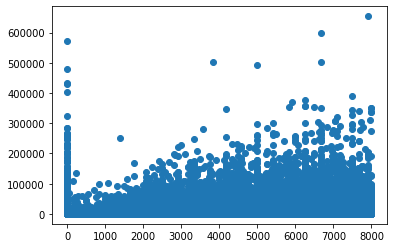

```python
#comparing monthly income and revolving credit balance
plt.scatter(x= df['StatedMonthlyIncome'], y= df['RevolvingCreditBalance'])
#noting outliers
```

```python
#viewing numbers on Stated Monthly Income
df['StatedMonthlyIncome'].describe()
```

```
count    94733.000000
mean      4256.402119
std       1824.948135
min          0.000000
25%       2916.666667
50%       4166.666667
75%       5646.833333
max       8000.000000
Name: StatedMonthlyIncome, dtype: float64
```

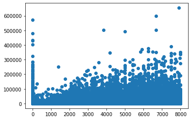

```python
#reassessing previous plot
plt.scatter(x= df['StatedMonthlyIncome'], y= df['RevolvingCreditBalance'])
#note:in general, the lower the monthly income, the revolving credit balance is lower the lower the income is
```

Observation: In general, the lower the monthly income, the lower the revolving credit balance. The exception to this is that those with zero income tend to have a larger revolving credit balance.

Question: What else is affected by income?

### Factors affected by income

```python
df['StatedMonthlyIncome'].describe()
```

```
count    94733.000000
mean      4256.402119
std       1824.948135
min          0.000000
25%       2916.666667
50%       4166.666667
75%       5646.833333
max       8000.000000
Name: StatedMonthlyIncome, dtype: float64
```

```python
#creating df with upper half income
upper_half= df[df['StatedMonthlyIncome'] > 4666]
upper_half.describe()
```

|  | BorrowerAPR | ProsperRating (numeric) | ProsperScore | RevolvingCreditBalance | DebtToIncomeRatio | StatedMonthlyIncome | ProsperPrincipalBorrowed | MonthlyLoanPayment |
| --- | --- | --- | --- | --- | --- | --- | --- | --- |
| count | 37948.000000 | 30406.000000 | 30406.000000 | 36125.000000 | 36058.000000 | 37952.000000 | 7727.000000 | 37952.000000 |
| mean | 0.210927 | 4.269453 | 6.145695 | 18434.356595 | 0.225713 | 6084.704214 | 9090.506316 | 302.440052 |
| std | 0.078452 | 1.632604 | 2.363891 | 25985.487949 | 0.118758 | 931.507370 | 7496.199570 | 186.147711 |
| min | 0.013150 | 1.000000 | 1.000000 | 0.000000 | 0.000000 | 4666.500000 | 1000.000000 | 0.000000 |
| 25% | 0.149650 | 3.000000 | 4.000000 | 4497.000000 | 0.140000 | 5250.000000 | 4000.000000 | 161.127500 |
| 50% | 0.202000 | 4.000000 | 6.000000 | 10986.000000 | 0.210000 | 6000.000000 | 7000.000000 | 272.705000 |
| 75% | 0.268770 | 6.000000 | 8.000000 | 22677.000000 | 0.290000 | 6750.000000 | 12500.000000 | 410.030000 |
| max | 0.413550 | 7.000000 | 11.000000 | 654260.000000 | 5.210000 | 8000.000000 | 65000.000000 | 2111.780000 |

```python
#creating df with lower half of income
lower_half= df[df['StatedMonthlyIncome'] < 4666]
lower_half.describe()
```

|  | BorrowerAPR | ProsperRating (numeric) | ProsperScore | RevolvingCreditBalance | DebtToIncomeRatio | StatedMonthlyIncome | ProsperPrincipalBorrowed | MonthlyLoanPayment |
| --- | --- | --- | --- | --- | --- | --- | --- | --- |
| count | 56772.000000 | 38394.000000 | 38394.000000 | 51873.000000 | 51420.000000 | 56778.000000 | 10134.000000 | 56778.000000 |
| mean | 0.232378 | 3.669219 | 5.470282 | 10000.481696 | 0.344676 | 3034.292324 | 6485.401486 | 207.825331 |
| std | 0.080071 | 1.632353 | 2.217056 | 16374.567284 | 0.774232 | 1117.515112 | 5534.030937 | 141.260371 |
| min | 0.006530 | 1.000000 | 1.000000 | 0.000000 | 0.000440 | 0.000000 | 0.000000 | 0.000000 |
| 25% | 0.169930 | 2.000000 | 4.000000 | 1855.000000 | 0.160000 | 2375.000000 | 3000.000000 | 108.330000 |
| 50% | 0.227410 | 4.000000 | 5.000000 | 5673.000000 | 0.250000 | 3191.666667 | 5000.000000 | 171.370000 |
| 75% | 0.295370 | 5.000000 | 7.000000 | 12043.000000 | 0.360000 | 3958.333333 | 8000.000000 | 282.800000 |
| max | 0.512290 | 7.000000 | 11.000000 | 573692.000000 | 10.010000 | 4665.416667 | 67000.000000 | 1382.130000 |

## Multi-variate exploration

Question: is there a correlation between Prosper rating, Prosper score, debt to income ratio, and monthly income?

```python
#creating a dataframe with just the variables I want to use.
final3=df.drop(columns=['CreditGrade', 'LoanStatus', 'ProsperPrincipalBorrowed', 'BorrowerAPR', 'IsBorrowerHomeowner', 'RevolvingCreditBalance', 'MonthlyLoanPayment'])
```

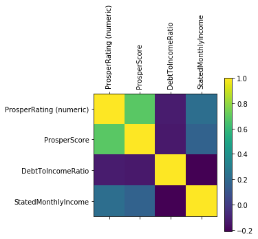

```python
#creating a correlation matrix (heat map)
plt.matshow(final3.corr())
plt.xticks(range(len(final3.columns)), final3.columns, rotation=90)
plt.yticks(range(len(final3.columns)), final3.columns)
plt.colorbar()
plt.figsize=(30,30)
plt.show()
```

Observation: The only significant correlation present is between the Prosper rating and the Prosper score. There is a slight correlation between monthly income and Prosper rating, Prosper score. There is a slight negative correlation between debt to income ratio and all other variables explored here.

Question: Is there a relationship between APR, monthly income, and debt to income ratio?

```python
#creating dataframe with only columns I want to use
multi_scatter= df.drop(columns= ['CreditGrade', 'LoanStatus', 'ProsperRating (numeric)',
       'ProsperScore', 'IsBorrowerHomeowner', 'RevolvingCreditBalance',
        'ProsperPrincipalBorrowed',
       'MonthlyLoanPayment'])
```

```
array([[<matplotlib.axes._subplots.AxesSubplot object at 0x000001FED3B19AC8>,
      dtype=object)
```

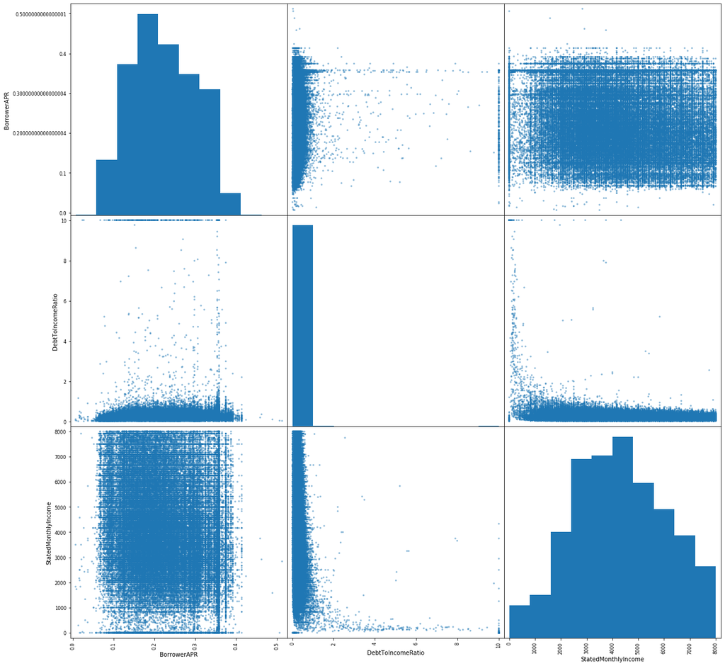

```python
#creating a scatter matrix
pd.plotting.scatter_matrix(multi_scatter, figsize= (20,20))
```

Observations: There does not seem to be a correlation between income and APR. Those with high APRs tend to have a higher debt to income ratio. Those with a lower monthly income tend to have a higher debt to income ratio.

### References

Prosper Loan Data - Variable Definitions. (n.d.). Retrieved December 15, 2019, from https://docs.google.com/spreadsheets/d/1gDyi_L4UvIrLTEC6Wri5nbaMmkGmLQBk-Yx3z0XDEtI/edit#gid=0.